# R-Ladies Ames Launch Party!

15 Dec 2016

## Outline

1. R-Ladies Global
2. R-Ladies Ames
3. Get to know each other
4. First meeting topic
5. Socializing

## R-Ladies Global

"R-Ladies is a worldwide organization whose mission is to promote Gender Diversity in the R community""

Women are underrepresented in every role:

- package developers
- conference speakers
- conference participants
- leadership positions
- ….

The aim of R-Ladies Global is to encourage women to be more represented throughout the R Community.

## R-Ladies Global

- R-Ladies was founded by Gabriela de Queiroz in San Francisco in October 2012!
- Today there are groups in 25 cities around the world

[figure not shown]

## R-Ladies Organization Structure

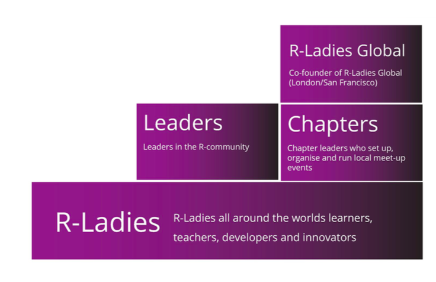

## Want to know more?

Web presence:

- Website: http://www.rladies.org
- E-mail: info@rladies.org
- Twitter: @RLadiesGlobal
- GitHub: http://github.com/rladies
- Global directory of female R practitioners / speakers: https://rladies.org/ladies/

## R-Ladies Ames

- Ames chapter: November 2016
- 40 members now!

Organizers:

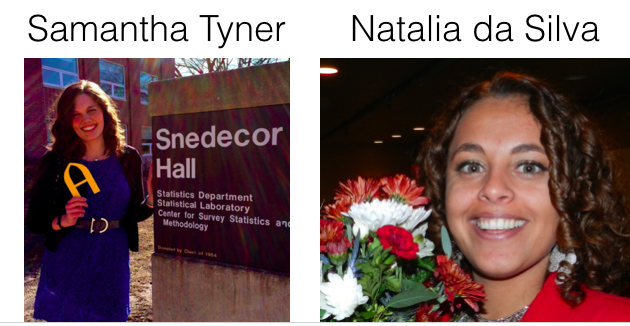

- Twitter: @RLadiesAmes
- E-mail: ames@rladies.org
- Meetup: http://meetup.com/R-Ladies-Ames/

## R-Ladies Ames: Meeting frequency

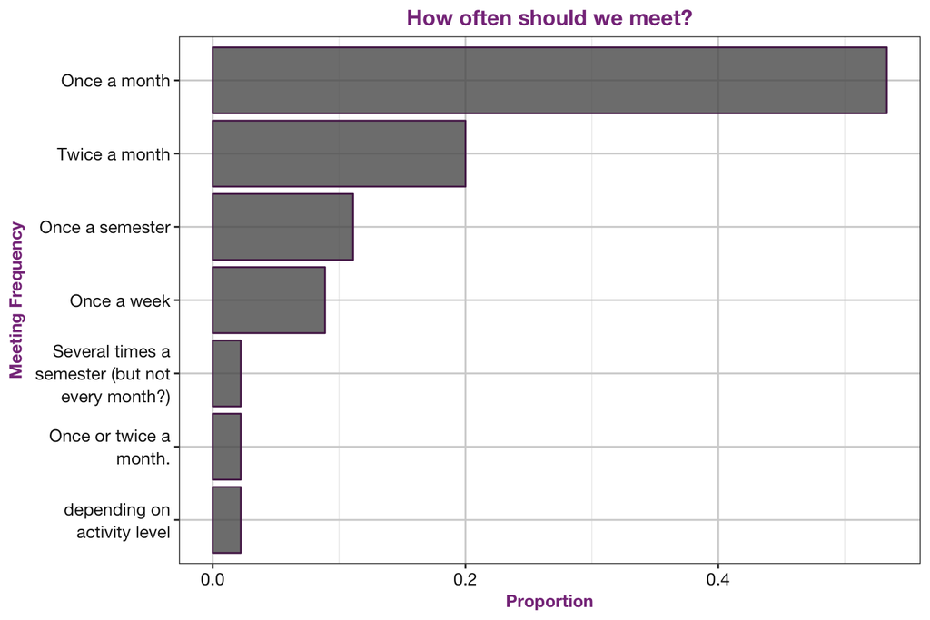

## R-Ladies Ames: Why?

What do you hope to gain from the meetings?

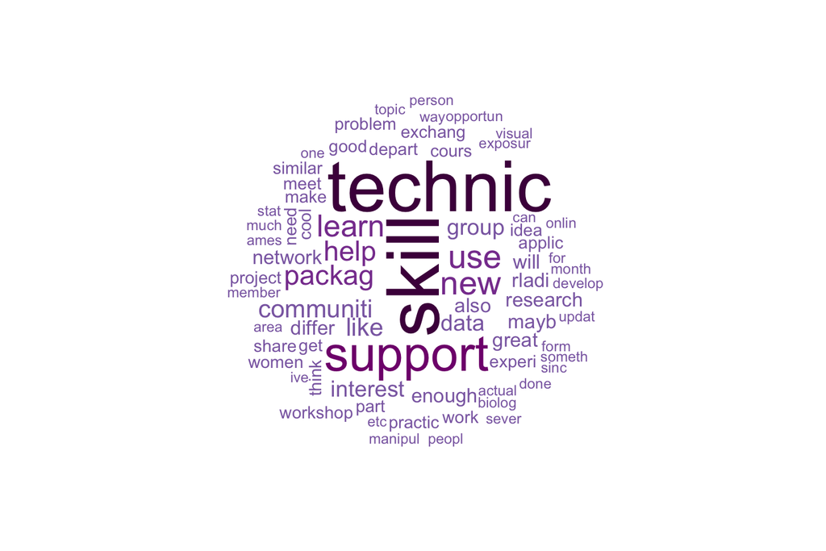

## R-Ladies Ames: What?

What would you like to learn about `R`?

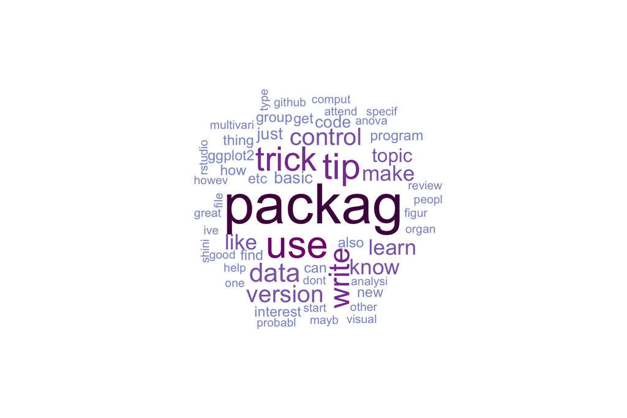

## R-Ladies Ames: Getting to know you

- Affiliated with Iowa State OR an outside company?
- Cat person OR dog person?
- Have/are working on a degree in Statistics OR another area?
- Chocolate ice cream OR vanilla ice cream?
- To plot in `R`: `base` plot OR `ggplot2` OR `lattice`?

## R-Ladies Ames: First Meeting Topic

Getting and cleaning data from the Web

- Scraping data using `rvest`
- Reading and cleaning untidy files in `R`
  - Reading Excel files into `R` with `readxl`
  - Cleaning data with the `tidyverse` packages: `dplyr`, `tidyr`, `purrr`

[figure not shown]

## R-Ladies Ames: Socializing

Enjoy the treats!

[figure not shown]